# EDA project

Math 685 students

9/20/2019

Is there a relationship between the year the house was sold and the sale price?

First, let’s look at the distribution of the year the house was sold.

```r
summary(ames_clean$Yr.Sold)
```

```
##    Min. 1st Qu.  Median    Mean 3rd Qu.    Max.
##    2006    2007    2008    2008    2009    2010
```

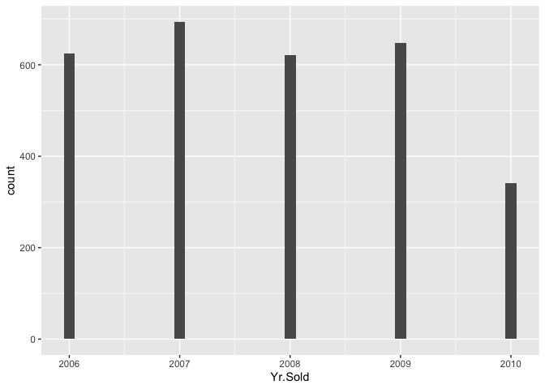

```r
ggplot(data = ames_clean, mapping = aes(x = Yr.Sold)) +
  geom_histogram(binwidth = 0.1)
```

Looking between 2006 and 2010, it looks like more houses were sold in 2007 (n=694) and the least amount of houses were sold in 2010 (n=341).

Now to look at sale price.

```r
summary(ames_clean$SalePrice)
```

```
##    Min. 1st Qu.  Median    Mean 3rd Qu.    Max.
##   12789  129500  160000  180796  213500  755000
```

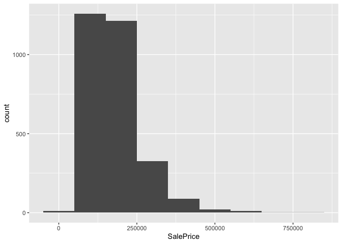

```r
ggplot(data = ames_clean, mapping = aes(x = SalePrice)) +
  geom_histogram(binwidth = 100000)
```

The lowest sale price was $12,789 and the highest was $755,000. The average sale price was $180,796.

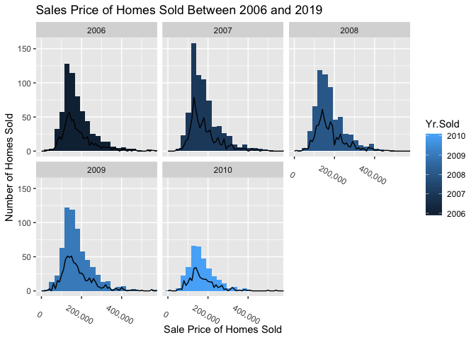

```r
ggplot(ames_clean, aes(x=SalePrice, fill=Yr.Sold)) +
    geom_histogram() +
    facet_wrap(~Yr.Sold)+
  geom_freqpoly(binwidth = 10000)+  ## im not sure I understand why
  coord_cartesian(xlim = c(0, 550000))+
  xlab("Sale Price of Homes Sold") +
  ylab("Number of Homes Sold") +
  ggtitle("Sales Price of Homes Sold Between 2006 and 2019") +
  scale_y_continuous(labels = scales::comma) +
  scale_x_continuous(labels = scales::comma) +
  theme(axis.text.x = element_text(angle=-30))
```

(I feel that this might make more sense if I broke these out by year?)

### Is there a relationship between the price of the hold sold and the lot area?

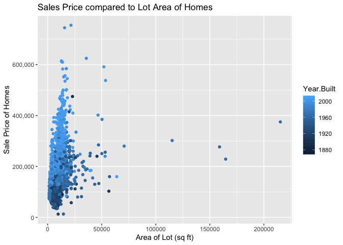

```r
ggplot(ames_clean, aes(x=Lot.Area, y=SalePrice, color=Year.Built)) +
  geom_point() +
  xlab("Area of Lot (sq ft)") +
  ylab("Sale Price of Homes") +
  ggtitle("Sales Price compared to Lot Area of Homes") +
  scale_y_continuous(labels = scales::comma)
```

It seems there is a positive relationship, however this graph shows us some extreme outliers above 150,000 sq ft (assuming sq ft) with respect to the lot area of the home. Most homes are below 25,000 sq ft which is just above 1/2 acre lot size (1 acre = 43,560 sq ft). The expensive homes also seem to be built more recently.